# Lab 3

Jonathan Bonaguro

February 12, 2020

## `Plantgrowth`

For this exercise, we will use practice plotting different types of graphs on multiple built-in datasets in R.

- Take a look at the `PlantGrowth` dataset by typing it in the console.
- Use the `table()` function to get counts on the number of plants in each treatment groups.

```r
PlantGrowth
```

```
##    weight group
## 1    4.17  ctrl
## 2    5.58  ctrl
## 3    5.18  ctrl
## 4    6.11  ctrl
## 5    4.50  ctrl
## 6    4.61  ctrl
## 7    5.17  ctrl
## 8    4.53  ctrl
## 9    5.33  ctrl
## 10   5.14  ctrl
## 11   4.81  trt1
## 12   4.17  trt1
## 13   4.41  trt1
## 14   3.59  trt1
```

[output cut: 16 more lines]

```r
table(PlantGrowth$group)
```

```
##
## ctrl trt1 trt2
##   10   10   10
```

#### Histogram

- Plot one histogram of dried weigth (`weight`) of plants from all 3 treatment groups.

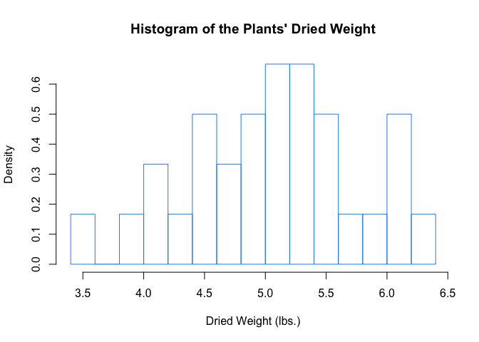

```r
hist(PlantGrowth$weight, main = "Histogram of the Plants' Dried Weight", xlab = "Dried Weight (lbs.)", ylab = "Density", probability = TRUE, border = "dodgerblue", breaks = 10)
```

#### Boxplot

- To compare the treatments, we want to have a plot that can compare the dried weight of plants from each treatment group.
- Plot a boxplot of `Weight` vs. `Group`.

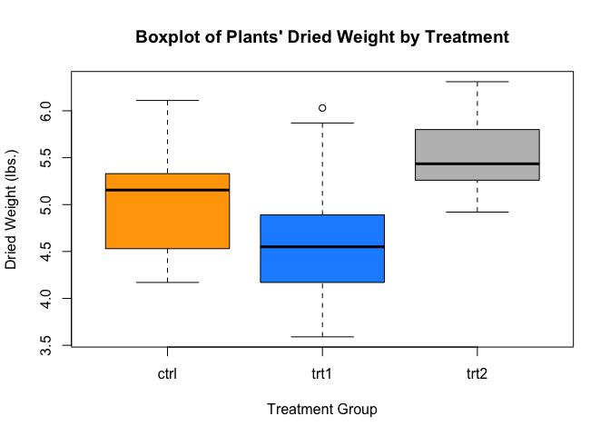

```r
boxplot(weight ~ group, data = PlantGrowth, main = "Boxplot of Plants' Dried Weight by Treatment", xlab = "Treatment Group", ylab = "Dried Weight (lbs.)", col = c("orange", "dodgerblue", "gray"))
```

## `trees`

- Next, we’re taking a look at the `trees` dataset.

#### Scatterplot

- Plot a scatterplot of `Height` vs. `Girth` (tree diameter).

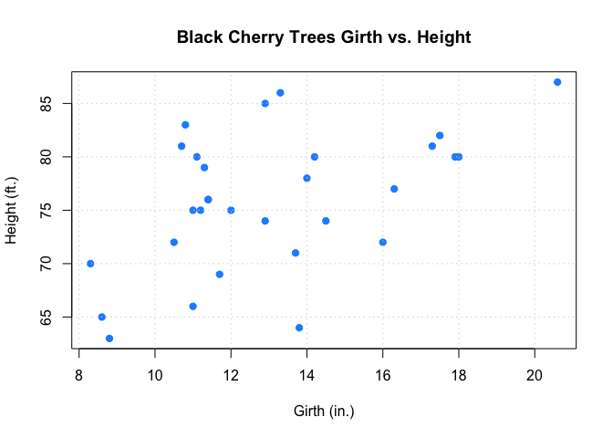

```r
plot(Height ~ Girth, data = trees, main = "Black Cherry Trees Girth vs. Height", xlab = "Girth (in.)", ylab = "Height (ft.)", col = "dodgerblue", pch = 19)
grid()
```

#### Boxplot

- To get summary statistics from a vector (or a column of a data frame, which is a vector), we can use `fivenum()`.
- For example, the five main summary statistics of Black Cherry Trees’ Girth are

```r
fivenum(trees$Girth)
```

```
## [1]  8.30 11.05 12.90 15.25 20.60
```

```r
trees$Group <- cut(trees$Girth, breaks = c(8.3, 11.05, 12.90, 15.25, 20.60), labels = c("group1", "group2", "group3", "group4"), right = FALSE, include.lowest = TRUE)
table(trees$Group)
```

```
##
## group1 group2 group3 group4
##      8      7      8      8
```

- Now, plot a boxplot of `Height` vs. `Group`.

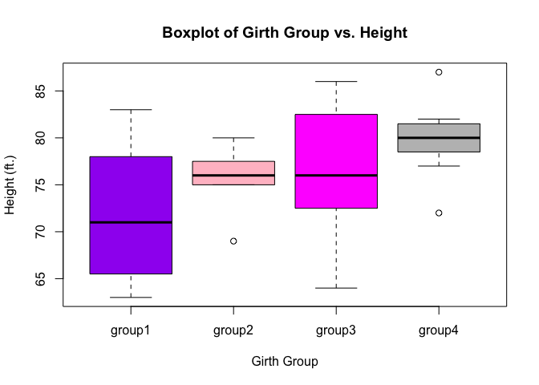

```r
boxplot(Height ~ Group, data = trees, main = "Boxplot of Girth Group vs. Height", xlab = "Girth Group", ylab = "Height (ft.)", col = c("purple", "pink", "magenta", "gray"))
```

## `warpbreaks`

- Use `str()` to take a quick look at the `warpbreaks` dataset.
- Use `table()` to count how many experiments were done for each combination of `wool` and `tension`.

```r
str(warpbreaks)
```

```
## 'data.frame':    54 obs. of  3 variables:
##  $ breaks : num  26 30 54 25 70 52 51 26 67 18 ...
##  $ wool   : Factor w/ 2 levels "A","B": 1 1 1 1 1 1 1 1 1 1 ...
##  $ tension: Factor w/ 3 levels "L","M","H": 1 1 1 1 1 1 1 1 1 2 ...
```

```r
table(warpbreaks$wool, warpbreaks$tension)
```

```
##
##     L M H
##   A 9 9 9
##   B 9 9 9
```

#### Histogram

- Plot a histogram of the number of breaks breaks for all combination of `wool` and `tension`.

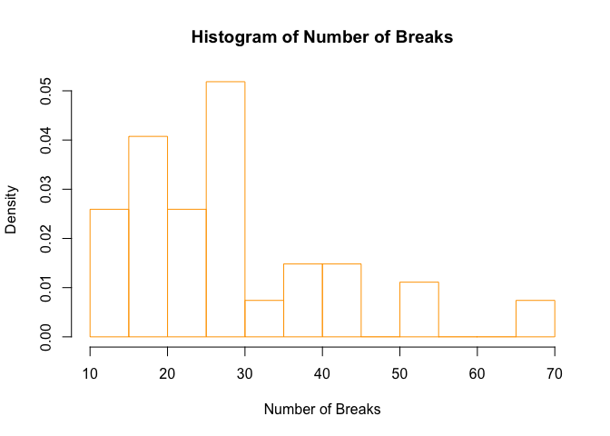

```r
hist(warpbreaks$breaks, main = "Histogram of Number of Breaks", xlab = "Number of Breaks", ylab = "Density", probability = TRUE, border = "orange", breaks = 20)
```

#### Boxplot

- Plot a boxplot of `breaks` vs. `tension`.

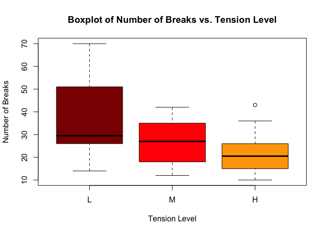

```r
boxplot(breaks ~ tension, data = warpbreaks, main = "Boxplot of Number of Breaks vs. Tension Level", xlab = "Tension Level", ylab = "Number of Breaks", col = c("darkred", "red", "orange"))
```

#### Another Boxplot

- Plot a boxplot of `breaks` vs. `wool`.

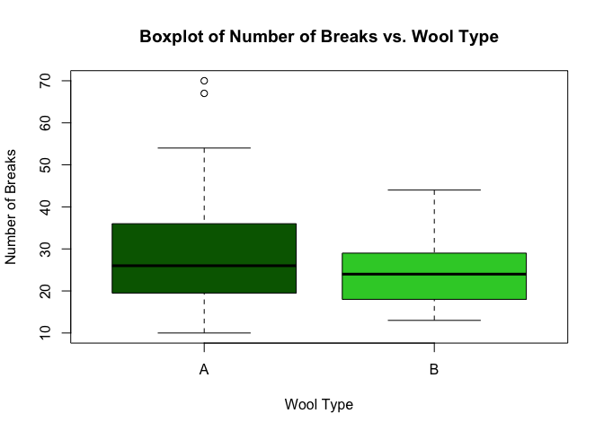

```r
boxplot(breaks ~ wool, data = warpbreaks, main = "Boxplot of Number of Breaks vs. Wool Type", xlab = "Wool Type", ylab = "Number of Breaks", col = c("darkgreen", "limegreen"))
```

#### Another Boxplot (Again!)

- Now, plot a boxplot of `breaks` vs. combination of `wool` and `tension` (hint: `wool*tension`).

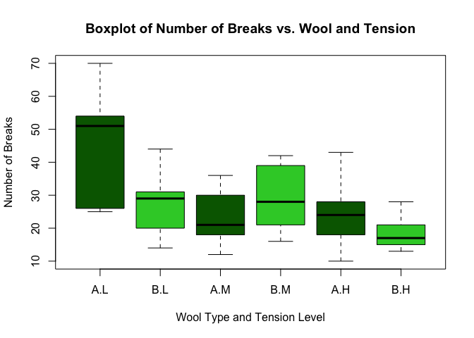

```r
boxplot(breaks ~ wool*tension, data = warpbreaks, main = "Boxplot of Number of Breaks vs. Wool and Tension", xlab = "Wool Type and Tension Level", ylab = "Number of Breaks", col = c("darkgreen", "limegreen"))
```